# HW3

Roxanne Felig

2/8/2021

# Homework 03

You will analyze data looking at the relationship between **green reputation** and three personality traits–**compassion**, **intellectual curiosity**, and **openness to experiences**. The dataset includes data from **students** and **non-students**.

```r
dictionary <- readr::read_csv("/Users/roxannefelig/Desktop/progdata/hw-roxannefelig/HW3/green_dictionary.csv")
green_data <- readr::read_csv("/Users/roxannefelig/Desktop/progdata/hw-roxannefelig/HW3/green_data.csv")
library(tidyverse)
library(dplyr)
library(psych)
library(naniar)
library(reshape2)
library(scales)
View(dictionary)
View(green_data)
```

```r
###1. Inspect the item responses (e.g., with graphs or by summarizing distinct values). Is anything unusual?

str(green_data)
```

```
## tibble [373 × 37] (S3: spec_tbl_df/tbl_df/tbl/data.frame)
##  $ id     : chr [1:373] "9099" "6275" "8116" "8586" ...
##  $ green1 : num [1:373] 4 3 4 4 3 4 1 4 4 4 ...
##  $ green2 : num [1:373] 2 5 2 3 2 3 1 3 2 2 ...
##  $ green3 : num [1:373] 5 3 5 5 4 4 1 2 3 5 ...
##  $ green4 : num [1:373] 4 3 4 4 4 4 1 2 5 5 ...
##  $ green5 : num [1:373] 3 1 3 3 4 3 1 2 2 4 ...
##  $ comp1  : num [1:373] 2 4 4 4 4 5 3 1 4 5 ...
##  $ comp2  : num [1:373] 5 5 5 5 4 5 3 1 4 2 ...
##  $ comp3  : num [1:373] 4 4 5 5 4 5 3 1 4 5 ...
##  $ comp4  : num [1:373] 4 5 4 4 4 4 3 2 4 4 ...
##  $ comp5  : num [1:373] 2 5 5 5 4 4 3 2 4 2 ...
##  $ comp6  : num [1:373] 2 1 1 1 2 2 3 4 1 2 ...
##  $ comp7  : num [1:373] 2 1 2 1 2 4 3 4 2 2 ...
##  $ comp8  : num [1:373] 2 1 2 2 2 1 3 4 1 2 ...
##  $ comp9  : num [1:373] 2 1 2 1 2 2 3 3 2 2 ...
##  $ comp10 : num [1:373] 2 1 2 2 2 2 3 3 2 2 ...
##  $ intel1 : num [1:373] 4 4 4 2 2 4 3 4 4 4 ...
##  $ intel2 : num [1:373] 2 4 4 2 4 4 3 4 4 4 ...
##  $ intel3 : num [1:373] 2 3 4 4 4 3 3 4 4 4 ...
##  $ intel4 : num [1:373] 2 4 3 4 4 4 3 4 4 2 ...
##  $ intel5 : num [1:373] 2 4 4 4 4 5 3 5 3 4 ...
##  $ intel6 : num [1:373] 2 4 3 3 4 2 3 4 3 4 ...
##  $ intel7 : num [1:373] 3 3 3 4 2 2 3 2 1 2 ...
##  $ intel8 : num [1:373] 1 3 3 1 1 2 3 2 1 3 ...
##  $ intel9 : num [1:373] 2 3 2 4 2 2 3 1 2 2 ...
##  $ intel10: num [1:373] 4 3 2 4 4 2 3 1 2 2 ...
##  $ open1  : num [1:373] 5 4 5 5 5 4 3 1 5 5 ...
##  $ open2  : num [1:373] 4 4 4 3 4 4 3 2 4 5 ...
##  $ open3  : num [1:373] 2 3 3 4 2 2 3 2 4 2 ...
##  $ open4  : num [1:373] 4 5 5 4 4 5 3 4 5 4 ...
##  $ open5  : num [1:373] 3 3 5 4 4 4 3 1 5 5 ...
##  $ open6  : num [1:373] 4 4 2 2 4 4 3 1 -99 1 ...
##  $ open7  : num [1:373] 2 4 2 2 4 2 3 5 3 2 ...
##  $ open8  : num [1:373] 4 5 2 2 2 2 3 4 2 2 ...
##  $ open9  : num [1:373] 1 4 2 1 2 3 3 3 1 2 ...
##  $ open10 : num [1:373] 4 3 3 2 2 2 3 5 2 2 ...
##  $ student: num [1:373] 2 2 2 2 2 2 2 2 1 2 ...
##  - attr(*, "spec")=
##   .. cols(
```

[output cut: 23 more lines]

```
##   ..   intel8 = col_double(),
##   ..   intel9 = col_double(),
##   ..   intel10 = col_double(),
##   ..   open1 = col_double(),
##   ..   open2 = col_double(),
##   ..   open3 = col_double(),
##   ..   open4 = col_double(),
##   ..   open5 = col_double(),
##   ..   open6 = col_double(),
##   ..   open7 = col_double(),
##   ..   open8 = col_double(),
##   ..   open9 = col_double(),
##   ..   open10 = col_double(),
##   ..   student = col_double()
##   .. )
```

```r
summary(green_data) #I notice that some missing values are coded as NA while others are coded as -99, so I'm going to re-code the -99s as NAs.
```

```
##       id                green1          green2         green3
##  Length:373         Min.   :1.000   Min.   :1.00   Min.   :1.000
##  Class :character   1st Qu.:3.000   1st Qu.:2.00   1st Qu.:3.000
##  Mode  :character   Median :4.000   Median :3.00   Median :4.000
##                     Mean   :3.476   Mean   :2.93   Mean   :3.797
##                     3rd Qu.:4.000   3rd Qu.:4.00   3rd Qu.:4.000
##                     Max.   :5.000   Max.   :5.00   Max.   :5.000
##                     NA's   :58      NA's   :58     NA's   :58
##      green4          green5          comp1             comp2
##  Min.   :1.000   Min.   :1.000   Min.   :-99.000   Min.   :-99.000
##  1st Qu.:3.000   1st Qu.:2.000   1st Qu.:  4.000   1st Qu.:  4.000
##  Median :3.000   Median :3.000   Median :  4.000   Median :  4.000
##  Mean   :3.238   Mean   :2.835   Mean   :  3.648   Mean   :  3.702
##  3rd Qu.:4.000   3rd Qu.:4.000   3rd Qu.:  4.000   3rd Qu.:  4.500
##  Max.   :5.000   Max.   :5.000   Max.   :  5.000   Max.   :  5.000
##  NA's   :58      NA's   :58      NA's   :86        NA's   :78
##      comp3           comp4             comp5             comp6
##  Min.   :1.000   Min.   :-99.000   Min.   :-99.000   Min.   :1.000
##  1st Qu.:4.000   1st Qu.:  4.000   1st Qu.:  4.000   1st Qu.:2.000
##  Median :4.000   Median :  4.000   Median :  4.000   Median :2.000
##  Mean   :4.267   Mean   :  3.691   Mean   :  3.319   Mean   :2.161
##  3rd Qu.:5.000   3rd Qu.:  4.000   3rd Qu.:  4.000   3rd Qu.:3.000
##  Max.   :5.000   Max.   :  5.000   Max.   :  5.000   Max.   :5.000
##  NA's   :77      NA's   :85        NA's   :88        NA's   :81
##      comp7            comp8             comp9             comp10
##  Min.   :-99.00   Min.   :-99.000   Min.   :-99.000   Min.   :-99.000
##  1st Qu.:  2.00   1st Qu.:  2.000   1st Qu.:  2.000   1st Qu.:  1.000
##  Median :  2.00   Median :  2.000   Median :  2.000   Median :  2.000
##  Mean   :  1.84   Mean   :  1.739   Mean   :  1.342   Mean   :  1.577
##  3rd Qu.:  3.00   3rd Qu.:  2.000   3rd Qu.:  2.000   3rd Qu.:  2.000
##  Max.   :  5.00   Max.   :  5.000   Max.   :  5.000   Max.   :  5.000
##  NA's   :86       NA's   :90        NA's   :89        NA's   :89
##      intel1           intel2            intel3            intel4
##  Min.   :-99.00   Min.   :-99.000   Min.   :-99.000   Min.   :-99.000
##  1st Qu.:  3.00   1st Qu.:  3.000   1st Qu.:  3.000   1st Qu.:  3.000
##  Median :  4.00   Median :  4.000   Median :  4.000   Median :  4.000
##  Mean   :  3.38   Mean   :  3.336   Mean   :  2.822   Mean   :  2.656
##  3rd Qu.:  4.00   3rd Qu.:  4.000   3rd Qu.:  4.000   3rd Qu.:  4.000
##  Max.   :  5.00   Max.   :  5.000   Max.   :  5.000   Max.   :  5.000
##  NA's   :78       NA's   :90        NA's   :86        NA's   :88
```

[output cut: 25 more lines]

```
##  Min.   :-99.000   Min.   :1.000   Min.   :1.000   Min.   :-99.00
##  1st Qu.:  2.000   1st Qu.:2.000   1st Qu.:2.000   1st Qu.:  2.00
##  Median :  3.000   Median :2.000   Median :2.000   Median :  2.00
##  Mean   :  2.274   Mean   :2.599   Mean   :2.568   Mean   :  2.36
##  3rd Qu.:  4.000   3rd Qu.:3.000   3rd Qu.:4.000   3rd Qu.:  4.00
##  Max.   :  5.000   Max.   :5.000   Max.   :5.000   Max.   :  5.00
##  NA's   :85        NA's   :84      NA's   :77      NA's   :90
##     student
##  Min.   :-99.000
##  1st Qu.:  1.000
##  Median :  2.000
##  Mean   :  1.309
##  3rd Qu.:  2.000
##  Max.   :  2.000
##  NA's   :95
```

```r
data<-green_data %>%
  mutate_at(vars(comp1:student),
         ~ifelse(. == -99, NA, .)
  )

summary(data) #now we see that the min values for variables are 1, not -99.
```

```
##       id                green1          green2         green3
##  Length:373         Min.   :1.000   Min.   :1.00   Min.   :1.000
##  Class :character   1st Qu.:3.000   1st Qu.:2.00   1st Qu.:3.000
##  Mode  :character   Median :4.000   Median :3.00   Median :4.000
##                     Mean   :3.476   Mean   :2.93   Mean   :3.797
##                     3rd Qu.:4.000   3rd Qu.:4.00   3rd Qu.:4.000
##                     Max.   :5.000   Max.   :5.00   Max.   :5.000
##                     NA's   :58      NA's   :58     NA's   :58
##      green4          green5          comp1           comp2
##  Min.   :1.000   Min.   :1.000   Min.   :1.000   Min.   :1.000
##  1st Qu.:3.000   1st Qu.:2.000   1st Qu.:4.000   1st Qu.:4.000
##  Median :3.000   Median :3.000   Median :4.000   Median :4.000
##  Mean   :3.238   Mean   :2.835   Mean   :4.007   Mean   :4.051
##  3rd Qu.:4.000   3rd Qu.:4.000   3rd Qu.:4.000   3rd Qu.:4.750
##  Max.   :5.000   Max.   :5.000   Max.   :5.000   Max.   :5.000
##  NA's   :58      NA's   :58      NA's   :87      NA's   :79
##      comp3           comp4           comp5           comp6
##  Min.   :1.000   Min.   :1.000   Min.   :1.000   Min.   :1.000
##  1st Qu.:4.000   1st Qu.:4.000   1st Qu.:4.000   1st Qu.:2.000
##  Median :4.000   Median :4.000   Median :4.000   Median :2.000
##  Mean   :4.267   Mean   :4.049   Mean   :4.042   Mean   :2.161
##  3rd Qu.:5.000   3rd Qu.:4.000   3rd Qu.:4.000   3rd Qu.:3.000
##  Max.   :5.000   Max.   :5.000   Max.   :5.000   Max.   :5.000
##  NA's   :77      NA's   :86      NA's   :90      NA's   :81
##      comp7           comp8           comp9           comp10
##  Min.   :1.000   Min.   :1.000   Min.   :1.000   Min.   :1.000
##  1st Qu.:2.000   1st Qu.:2.000   1st Qu.:2.000   1st Qu.:1.000
##  Median :2.000   Median :2.000   Median :2.000   Median :2.000
##  Mean   :2.192   Mean   :2.096   Mean   :2.053   Mean   :1.933
##  3rd Qu.:3.000   3rd Qu.:2.000   3rd Qu.:2.000   3rd Qu.:2.000
##  Max.   :5.000   Max.   :5.000   Max.   :5.000   Max.   :5.000
##  NA's   :87      NA's   :91      NA's   :91      NA's   :90
##      intel1          intel2          intel3          intel4
##  Min.   :1.000   Min.   :1.000   Min.   :1.000   Min.   :1.000
##  1st Qu.:3.000   1st Qu.:3.000   1st Qu.:3.000   1st Qu.:3.000
##  Median :4.000   Median :4.000   Median :4.000   Median :4.000
##  Mean   :3.728   Mean   :3.699   Mean   :3.537   Mean   :3.375
##  3rd Qu.:4.000   3rd Qu.:4.000   3rd Qu.:4.000   3rd Qu.:4.000
##  Max.   :5.000   Max.   :5.000   Max.   :5.000   Max.   :5.000
##  NA's   :79      NA's   :91      NA's   :88      NA's   :90
```

[output cut: 17 more lines]

```
##  Min.   :1.000   Min.   :1.00   Min.   :1.00   Min.   :1.000   Min.   :1.000
##  1st Qu.:3.000   1st Qu.:3.00   1st Qu.:3.00   1st Qu.:3.000   1st Qu.:2.000
##  Median :4.000   Median :4.00   Median :4.00   Median :4.000   Median :3.000
##  Mean   :3.749   Mean   :3.92   Mean   :3.83   Mean   :3.592   Mean   :2.983
##  3rd Qu.:4.000   3rd Qu.:5.00   3rd Qu.:4.00   3rd Qu.:4.000   3rd Qu.:4.000
##  Max.   :5.000   Max.   :5.00   Max.   :5.00   Max.   :5.000   Max.   :5.000
##  NA's   :90      NA's   :86     NA's   :90     NA's   :86      NA's   :87
##      open8           open9           open10        student
##  Min.   :1.000   Min.   :1.000   Min.   :1.00   Min.   :1.000
##  1st Qu.:2.000   1st Qu.:2.000   1st Qu.:2.00   1st Qu.:1.000
##  Median :2.000   Median :2.000   Median :2.00   Median :2.000
##  Mean   :2.599   Mean   :2.568   Mean   :2.72   Mean   :1.671
##  3rd Qu.:3.000   3rd Qu.:4.000   3rd Qu.:4.00   3rd Qu.:2.000
##  Max.   :5.000   Max.   :5.000   Max.   :5.00   Max.   :2.000
##  NA's   :84      NA's   :77      NA's   :91     NA's   :96
```

```r
melt_data<-melt(data) #collapses data to one column
```

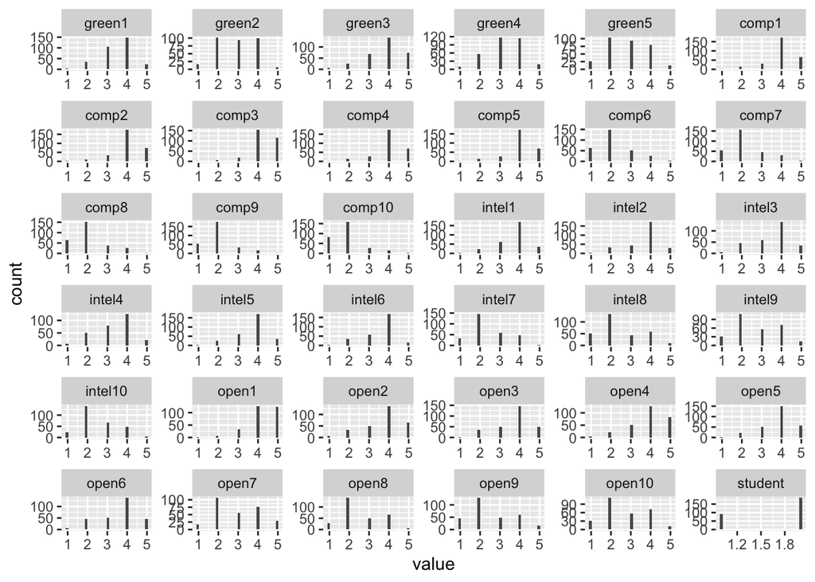

```r
View(melt_data)

#plotting using the melted data and the facet wrap will allow us to see histograms for each scale item, and the frequency of each response choice.

ggplot(melt_data)+
  aes(x=value)+
  geom_histogram()+
  facet_wrap(~variable,
             scales="free")
```

```r
### 2. Compute total scores for the four scales. Recode variables as needed.

#First, we need to reverse code items as indicated in the dictionary. The reverse coded items are green2,comp6:comp10, intel7:intel10,and open7:open10.
#two ways to reverse code shown below:

reversed1<- c("green2", "comp6", "comp7","comp8","comp9","comp10","intel7",
             "intel8","intel9","intel10","open7","open8","open9","open10")

reversed2 <- dictionary %>%
  filter(Keying == -1) %>%
  pull(Item)

data %>%
  mutate(
    across(all_of(reversed2),
           ~ recode(.x, "5" = 1, "4" = 2, "3" = 3, "2" = 4, "1" = 5),
           .names = "{.col}r")
  )
```

```
## # A tibble: 373 x 51
##    id    green1 green2 green3 green4 green5 comp1 comp2 comp3 comp4 comp5 comp6
##    <chr>  <dbl>  <dbl>  <dbl>  <dbl>  <dbl> <dbl> <dbl> <dbl> <dbl> <dbl> <dbl>
##  1 9099       4      2      5      4      3     2     5     4     4     2     2
##  2 6275       3      5      3      3      1     4     5     4     5     5     1
##  3 8116       4      2      5      4      3     4     5     5     4     5     1
##  4 8586       4      3      5      4      3     4     5     5     4     5     1
##  5 0406       3      2      4      4      4     4     4     4     4     4     2
##  6 5645       4      3      4      4      3     5     5     5     4     4     2
##  7 3788       1      1      1      1      1     3     3     3     3     3     3
##  8 8424       4      3      2      2      2     1     1     1     2     2     4
##  9 8450       4      2      3      5      2     4     4     4     4     4     1
## 10 0512       4      2      5      5      4     5     2     5     4     2     2
## # … with 363 more rows, and 39 more variables: comp7 <dbl>, comp8 <dbl>,
## #   comp9 <dbl>, comp10 <dbl>, intel1 <dbl>, intel2 <dbl>, intel3 <dbl>,
## #   intel4 <dbl>, intel5 <dbl>, intel6 <dbl>, intel7 <dbl>, intel8 <dbl>,
## #   intel9 <dbl>, intel10 <dbl>, open1 <dbl>, open2 <dbl>, open3 <dbl>,
## #   open4 <dbl>, open5 <dbl>, open6 <dbl>, open7 <dbl>, open8 <dbl>,
## #   open9 <dbl>, open10 <dbl>, student <dbl>, green2r <dbl>, comp6r <dbl>,
## #   comp7r <dbl>, comp8r <dbl>, comp9r <dbl>, comp10r <dbl>, intel7r <dbl>,
## #   intel8r <dbl>, intel9r <dbl>, intel10r <dbl>, open7r <dbl>, open8r <dbl>,
## #   open9r <dbl>, open10r <dbl>
```

```r
#total scores
summary(data)
```

```
##       id                green1          green2         green3
##  Length:373         Min.   :1.000   Min.   :1.00   Min.   :1.000
##  Class :character   1st Qu.:3.000   1st Qu.:2.00   1st Qu.:3.000
##  Mode  :character   Median :4.000   Median :3.00   Median :4.000
##                     Mean   :3.476   Mean   :2.93   Mean   :3.797
##                     3rd Qu.:4.000   3rd Qu.:4.00   3rd Qu.:4.000
##                     Max.   :5.000   Max.   :5.00   Max.   :5.000
##                     NA's   :58      NA's   :58     NA's   :58
##      green4          green5          comp1           comp2
##  Min.   :1.000   Min.   :1.000   Min.   :1.000   Min.   :1.000
##  1st Qu.:3.000   1st Qu.:2.000   1st Qu.:4.000   1st Qu.:4.000
##  Median :3.000   Median :3.000   Median :4.000   Median :4.000
##  Mean   :3.238   Mean   :2.835   Mean   :4.007   Mean   :4.051
##  3rd Qu.:4.000   3rd Qu.:4.000   3rd Qu.:4.000   3rd Qu.:4.750
##  Max.   :5.000   Max.   :5.000   Max.   :5.000   Max.   :5.000
##  NA's   :58      NA's   :58      NA's   :87      NA's   :79
##      comp3           comp4           comp5           comp6
##  Min.   :1.000   Min.   :1.000   Min.   :1.000   Min.   :1.000
##  1st Qu.:4.000   1st Qu.:4.000   1st Qu.:4.000   1st Qu.:2.000
##  Median :4.000   Median :4.000   Median :4.000   Median :2.000
##  Mean   :4.267   Mean   :4.049   Mean   :4.042   Mean   :2.161
##  3rd Qu.:5.000   3rd Qu.:4.000   3rd Qu.:4.000   3rd Qu.:3.000
##  Max.   :5.000   Max.   :5.000   Max.   :5.000   Max.   :5.000
##  NA's   :77      NA's   :86      NA's   :90      NA's   :81
##      comp7           comp8           comp9           comp10
##  Min.   :1.000   Min.   :1.000   Min.   :1.000   Min.   :1.000
##  1st Qu.:2.000   1st Qu.:2.000   1st Qu.:2.000   1st Qu.:1.000
##  Median :2.000   Median :2.000   Median :2.000   Median :2.000
##  Mean   :2.192   Mean   :2.096   Mean   :2.053   Mean   :1.933
##  3rd Qu.:3.000   3rd Qu.:2.000   3rd Qu.:2.000   3rd Qu.:2.000
##  Max.   :5.000   Max.   :5.000   Max.   :5.000   Max.   :5.000
##  NA's   :87      NA's   :91      NA's   :91      NA's   :90
##      intel1          intel2          intel3          intel4
##  Min.   :1.000   Min.   :1.000   Min.   :1.000   Min.   :1.000
##  1st Qu.:3.000   1st Qu.:3.000   1st Qu.:3.000   1st Qu.:3.000
##  Median :4.000   Median :4.000   Median :4.000   Median :4.000
##  Mean   :3.728   Mean   :3.699   Mean   :3.537   Mean   :3.375
##  3rd Qu.:4.000   3rd Qu.:4.000   3rd Qu.:4.000   3rd Qu.:4.000
##  Max.   :5.000   Max.   :5.000   Max.   :5.000   Max.   :5.000
##  NA's   :79      NA's   :91      NA's   :88      NA's   :90
```

[output cut: 17 more lines]

```
##  Min.   :1.000   Min.   :1.00   Min.   :1.00   Min.   :1.000   Min.   :1.000
##  1st Qu.:3.000   1st Qu.:3.00   1st Qu.:3.00   1st Qu.:3.000   1st Qu.:2.000
##  Median :4.000   Median :4.00   Median :4.00   Median :4.000   Median :3.000
##  Mean   :3.749   Mean   :3.92   Mean   :3.83   Mean   :3.592   Mean   :2.983
##  3rd Qu.:4.000   3rd Qu.:5.00   3rd Qu.:4.00   3rd Qu.:4.000   3rd Qu.:4.000
##  Max.   :5.000   Max.   :5.00   Max.   :5.00   Max.   :5.000   Max.   :5.000
##  NA's   :90      NA's   :86     NA's   :90     NA's   :86      NA's   :87
##      open8           open9           open10        student
##  Min.   :1.000   Min.   :1.000   Min.   :1.00   Min.   :1.000
##  1st Qu.:2.000   1st Qu.:2.000   1st Qu.:2.00   1st Qu.:1.000
##  Median :2.000   Median :2.000   Median :2.00   Median :2.000
##  Mean   :2.599   Mean   :2.568   Mean   :2.72   Mean   :1.671
##  3rd Qu.:3.000   3rd Qu.:4.000   3rd Qu.:4.00   3rd Qu.:2.000
##  Max.   :5.000   Max.   :5.000   Max.   :5.00   Max.   :2.000
##  NA's   :84      NA's   :77      NA's   :91     NA's   :96
```

```r
View(data)

#we will use the row wise function for this so that we can create total scores for each person.

new_data<-data %>%
  rowwise() %>%
  mutate(
    .id = id,
    green_total = mean(c_across(green1:green5), na.rm = TRUE),
    comp_total = mean(c_across(comp1:comp10), na.rm = TRUE),
    intel_total = mean(c_across(intel1:intel10), na.rm = TRUE),
    open_total = mean(c_across(open1:open10), na.rm = TRUE),
    .before = everything()
  )

summary(new_data)
```

```
##      .id             green_total      comp_total     intel_total
##  Length:373         Min.   :1.000   Min.   :1.900   Min.   :1.700
##  Class :character   1st Qu.:3.000   1st Qu.:3.000   1st Qu.:3.000
##  Mode  :character   Median :3.200   Median :3.100   Median :3.200
##                     Mean   :3.255   Mean   :3.117   Mean   :3.188
##                     3rd Qu.:3.600   3rd Qu.:3.200   3rd Qu.:3.400
##                     Max.   :4.400   Max.   :5.000   Max.   :4.500
##                     NA's   :58      NA's   :77      NA's   :77
##    open_total         id                green1          green2
##  Min.   :1.400   Length:373         Min.   :1.000   Min.   :1.00
##  1st Qu.:3.200   Class :character   1st Qu.:3.000   1st Qu.:2.00
##  Median :3.400   Mode  :character   Median :4.000   Median :3.00
##  Mean   :3.391                      Mean   :3.476   Mean   :2.93
##  3rd Qu.:3.600                      3rd Qu.:4.000   3rd Qu.:4.00
##  Max.   :5.000                      Max.   :5.000   Max.   :5.00
##  NA's   :77                         NA's   :58      NA's   :58
##      green3          green4          green5          comp1
##  Min.   :1.000   Min.   :1.000   Min.   :1.000   Min.   :1.000
##  1st Qu.:3.000   1st Qu.:3.000   1st Qu.:2.000   1st Qu.:4.000
##  Median :4.000   Median :3.000   Median :3.000   Median :4.000
##  Mean   :3.797   Mean   :3.238   Mean   :2.835   Mean   :4.007
##  3rd Qu.:4.000   3rd Qu.:4.000   3rd Qu.:4.000   3rd Qu.:4.000
##  Max.   :5.000   Max.   :5.000   Max.   :5.000   Max.   :5.000
##  NA's   :58      NA's   :58      NA's   :58      NA's   :87
##      comp2           comp3           comp4           comp5
##  Min.   :1.000   Min.   :1.000   Min.   :1.000   Min.   :1.000
##  1st Qu.:4.000   1st Qu.:4.000   1st Qu.:4.000   1st Qu.:4.000
##  Median :4.000   Median :4.000   Median :4.000   Median :4.000
##  Mean   :4.051   Mean   :4.267   Mean   :4.049   Mean   :4.042
##  3rd Qu.:4.750   3rd Qu.:5.000   3rd Qu.:4.000   3rd Qu.:4.000
##  Max.   :5.000   Max.   :5.000   Max.   :5.000   Max.   :5.000
##  NA's   :79      NA's   :77      NA's   :86      NA's   :90
##      comp6           comp7           comp8           comp9
##  Min.   :1.000   Min.   :1.000   Min.   :1.000   Min.   :1.000
##  1st Qu.:2.000   1st Qu.:2.000   1st Qu.:2.000   1st Qu.:2.000
##  Median :2.000   Median :2.000   Median :2.000   Median :2.000
##  Mean   :2.161   Mean   :2.192   Mean   :2.096   Mean   :2.053
##  3rd Qu.:3.000   3rd Qu.:3.000   3rd Qu.:2.000   3rd Qu.:2.000
##  Max.   :5.000   Max.   :5.000   Max.   :5.000   Max.   :5.000
##  NA's   :81      NA's   :87      NA's   :91      NA's   :91
```

[output cut: 25 more lines]

```
##  Min.   :1.000   Min.   :1.000   Min.   :1.00   Min.   :1.00   Min.   :1.000
##  1st Qu.:3.000   1st Qu.:3.000   1st Qu.:3.00   1st Qu.:3.00   1st Qu.:3.000
##  Median :4.000   Median :4.000   Median :4.00   Median :4.00   Median :4.000
##  Mean   :3.763   Mean   :3.749   Mean   :3.92   Mean   :3.83   Mean   :3.592
##  3rd Qu.:4.000   3rd Qu.:4.000   3rd Qu.:5.00   3rd Qu.:4.00   3rd Qu.:4.000
##  Max.   :5.000   Max.   :5.000   Max.   :5.00   Max.   :5.00   Max.   :5.000
##  NA's   :82      NA's   :90      NA's   :86     NA's   :90     NA's   :86
##      open7           open8           open9           open10        student
##  Min.   :1.000   Min.   :1.000   Min.   :1.000   Min.   :1.00   Min.   :1.000
##  1st Qu.:2.000   1st Qu.:2.000   1st Qu.:2.000   1st Qu.:2.00   1st Qu.:1.000
##  Median :3.000   Median :2.000   Median :2.000   Median :2.00   Median :2.000
##  Mean   :2.983   Mean   :2.599   Mean   :2.568   Mean   :2.72   Mean   :1.671
##  3rd Qu.:4.000   3rd Qu.:3.000   3rd Qu.:4.000   3rd Qu.:4.00   3rd Qu.:2.000
##  Max.   :5.000   Max.   :5.000   Max.   :5.000   Max.   :5.00   Max.   :2.000
##  NA's   :87      NA's   :84      NA's   :77      NA's   :91     NA's   :96
```

```r
##3 Rescale the variables so that they go from 0-100 instead of the original range.Name the rescaled variables `*_pomp`.

## I had trouble with this and did it two ways. I tried to rescale the variables after having mutated in the previod question, but it didn't add them into the new data set. So in my first chunk of code below, I made the total scores and then piped those into the rescale and it worked. Then I tried it a different way where I assigned the pomp values into a new data set, 'pomp_data', and it worked. I feel like there's probably an easier way to do this, so I'm eager to get some feedback.

new_data<-data %>%
  rowwise() %>%
  mutate(
    .id = id,
    green_total = mean(c_across(green1:green5), na.rm = TRUE),
    comp_total = mean(c_across(comp1:comp10), na.rm = TRUE),
    intel_total = mean(c_across(intel1:intel10), na.rm = TRUE),
    open_total = mean(c_across(open1:open10), na.rm = TRUE),
    .before = everything()
  ) %>%
  mutate(
  green_pomp=rescale(green_total, from= c(1,5), to = c(0, 100)),
  comp_pomp=rescale(comp_total, from= c(1,5), to = c(0, 100)),
  intel_pomp=rescale(intel_total, from= c(1,5), to = c(0, 100)),
  open_pomp=rescale(open_total, from= c(1,5), to = c(0, 100))
  )

summary(new_data)
```

```
##      .id             green_total      comp_total     intel_total
##  Length:373         Min.   :1.000   Min.   :1.900   Min.   :1.700
##  Class :character   1st Qu.:3.000   1st Qu.:3.000   1st Qu.:3.000
##  Mode  :character   Median :3.200   Median :3.100   Median :3.200
##                     Mean   :3.255   Mean   :3.117   Mean   :3.188
##                     3rd Qu.:3.600   3rd Qu.:3.200   3rd Qu.:3.400
##                     Max.   :4.400   Max.   :5.000   Max.   :4.500
##                     NA's   :58      NA's   :77      NA's   :77
##    open_total         id                green1          green2
##  Min.   :1.400   Length:373         Min.   :1.000   Min.   :1.00
##  1st Qu.:3.200   Class :character   1st Qu.:3.000   1st Qu.:2.00
##  Median :3.400   Mode  :character   Median :4.000   Median :3.00
##  Mean   :3.391                      Mean   :3.476   Mean   :2.93
##  3rd Qu.:3.600                      3rd Qu.:4.000   3rd Qu.:4.00
##  Max.   :5.000                      Max.   :5.000   Max.   :5.00
##  NA's   :77                         NA's   :58      NA's   :58
##      green3          green4          green5          comp1
##  Min.   :1.000   Min.   :1.000   Min.   :1.000   Min.   :1.000
##  1st Qu.:3.000   1st Qu.:3.000   1st Qu.:2.000   1st Qu.:4.000
##  Median :4.000   Median :3.000   Median :3.000   Median :4.000
##  Mean   :3.797   Mean   :3.238   Mean   :2.835   Mean   :4.007
##  3rd Qu.:4.000   3rd Qu.:4.000   3rd Qu.:4.000   3rd Qu.:4.000
##  Max.   :5.000   Max.   :5.000   Max.   :5.000   Max.   :5.000
##  NA's   :58      NA's   :58      NA's   :58      NA's   :87
##      comp2           comp3           comp4           comp5
##  Min.   :1.000   Min.   :1.000   Min.   :1.000   Min.   :1.000
##  1st Qu.:4.000   1st Qu.:4.000   1st Qu.:4.000   1st Qu.:4.000
##  Median :4.000   Median :4.000   Median :4.000   Median :4.000
##  Mean   :4.051   Mean   :4.267   Mean   :4.049   Mean   :4.042
##  3rd Qu.:4.750   3rd Qu.:5.000   3rd Qu.:4.000   3rd Qu.:4.000
##  Max.   :5.000   Max.   :5.000   Max.   :5.000   Max.   :5.000
##  NA's   :79      NA's   :77      NA's   :86      NA's   :90
##      comp6           comp7           comp8           comp9
##  Min.   :1.000   Min.   :1.000   Min.   :1.000   Min.   :1.000
##  1st Qu.:2.000   1st Qu.:2.000   1st Qu.:2.000   1st Qu.:2.000
##  Median :2.000   Median :2.000   Median :2.000   Median :2.000
##  Mean   :2.161   Mean   :2.192   Mean   :2.096   Mean   :2.053
##  3rd Qu.:3.000   3rd Qu.:3.000   3rd Qu.:2.000   3rd Qu.:2.000
##  Max.   :5.000   Max.   :5.000   Max.   :5.000   Max.   :5.000
##  NA's   :81      NA's   :87      NA's   :91      NA's   :91
```

[output cut: 33 more lines]

```
##  Min.   :1.000   Min.   :1.000   Min.   :1.000   Min.   :1.00   Min.   :1.000
##  1st Qu.:2.000   1st Qu.:2.000   1st Qu.:2.000   1st Qu.:2.00   1st Qu.:1.000
##  Median :3.000   Median :2.000   Median :2.000   Median :2.00   Median :2.000
##  Mean   :2.983   Mean   :2.599   Mean   :2.568   Mean   :2.72   Mean   :1.671
##  3rd Qu.:4.000   3rd Qu.:3.000   3rd Qu.:4.000   3rd Qu.:4.00   3rd Qu.:2.000
##  Max.   :5.000   Max.   :5.000   Max.   :5.000   Max.   :5.00   Max.   :2.000
##  NA's   :87      NA's   :84      NA's   :77      NA's   :91     NA's   :96
##    green_pomp      comp_pomp        intel_pomp      open_pomp
##  Min.   : 0.00   Min.   : 22.50   Min.   :17.50   Min.   : 10.00
##  1st Qu.:50.00   1st Qu.: 50.00   1st Qu.:50.00   1st Qu.: 55.00
##  Median :55.00   Median : 52.50   Median :55.00   Median : 60.00
##  Mean   :56.38   Mean   : 52.93   Mean   :54.71   Mean   : 59.76
##  3rd Qu.:65.00   3rd Qu.: 55.00   3rd Qu.:60.00   3rd Qu.: 65.00
##  Max.   :85.00   Max.   :100.00   Max.   :87.50   Max.   :100.00
##  NA's   :58      NA's   :77       NA's   :77      NA's   :77
```

```r
pomp_data<-new_data %>%
  mutate(
  green_pomp=rescale(green_total, from= c(1,5), to = c(0, 100)),
  comp_pomp=rescale(comp_total, from= c(1,5), to = c(0, 100)),
  intel_pomp=rescale(intel_total, from= c(1,5), to = c(0, 100)),
  open_pomp=rescale(open_total, from= c(1,5), to = c(0, 100))
  )
```

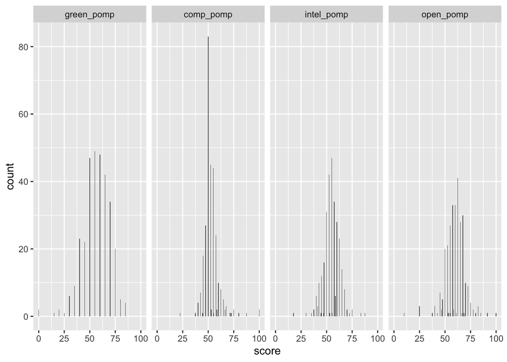

```r
##4. Makpe plots that illustrate the distributions of the 4 POMP-scored variables.


## I created a grid plot to see each variable side by side, but then made individual plots to be able to better see outliers plotted.

pomp_only<-pomp_data %>%
  select(.id, green_pomp,comp_pomp,intel_pomp, open_pomp)

plot_data<-melt(pomp_only,
                   value.name = "score",
                   variable.name = "POMP_var"
)
q4_graph<- ggplot(plot_data)+
  aes(x=score)+
  facet_grid(~POMP_var)+
  geom_histogram(binwidth = .5)

q4_graph
```

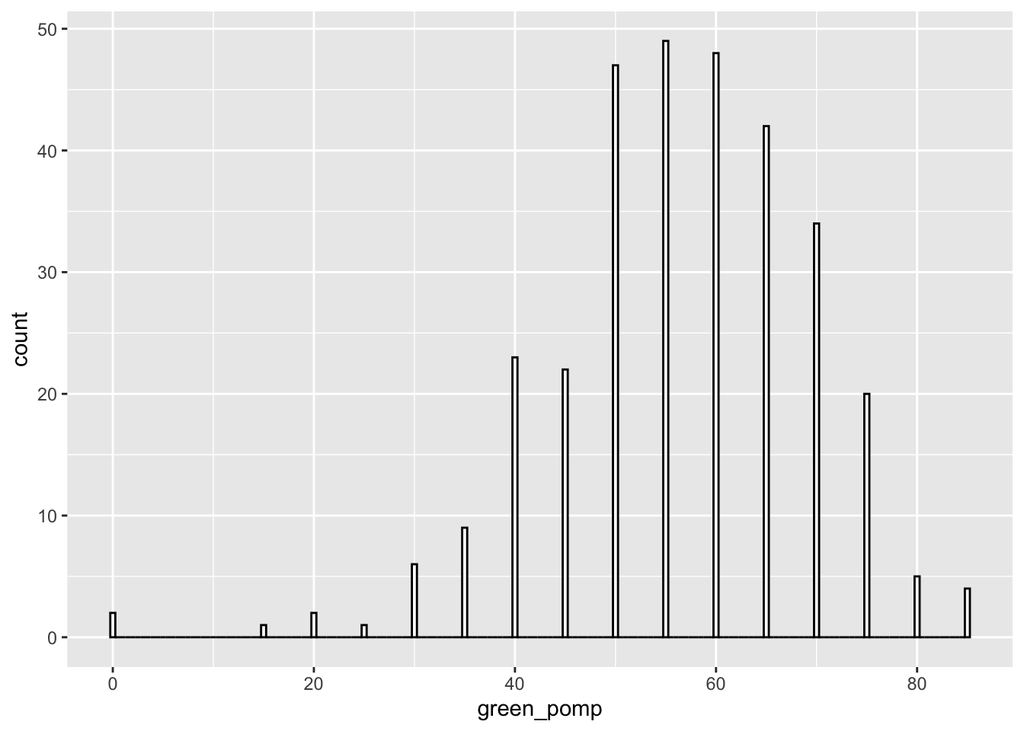

```r
green_plot<- ggplot(pomp_data, aes(x=green_pomp)) +
            geom_histogram(binwidth = .5,colour="black", fill="white")
green_plot
```

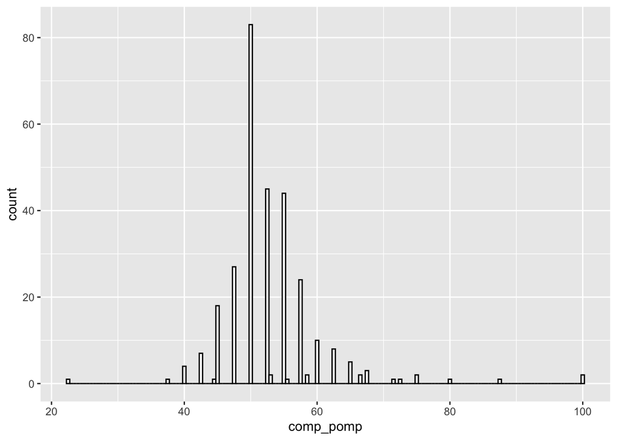

```r
comp_plot<- ggplot(pomp_data, aes(x=comp_pomp)) +
            geom_histogram(binwidth = .5,colour="black", fill="white")
comp_plot
```

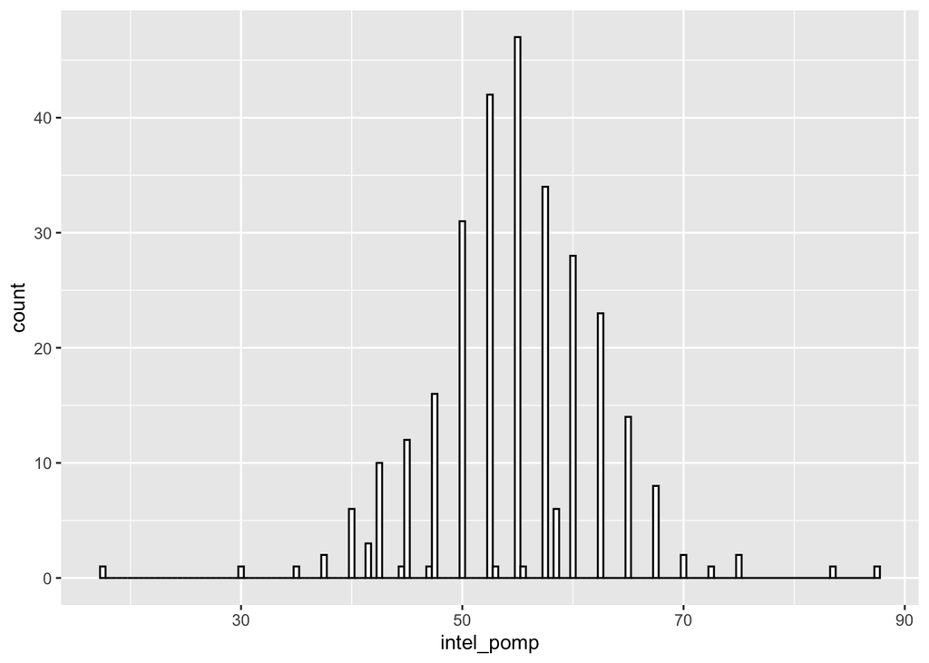

```r
intel_plot<- ggplot(pomp_data, aes(x=intel_pomp)) +
            geom_histogram(binwidth = .5,colour="black", fill="white")
intel_plot
```

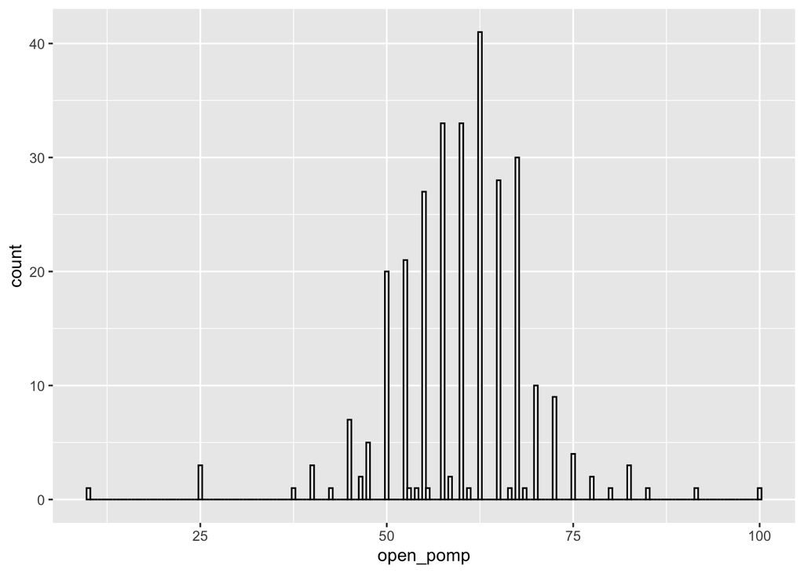

```r
open_plot<- ggplot(pomp_data, aes(x=open_pomp)) +
            geom_histogram(binwidth = .5,colour="black", fill="white")
open_plot
```

Intel and open look to follow a normal distribution. Green seems negatively skewed, and comp seems very clustered around 50, having more of a leptokurtic distribution.

All four variables seem to have some outliers that may need to be addressed.

```r
##  5. Make scatterplots showing the relationships between **green reputation** and each personality trait.

##Include trend lines for **students** and **non-students**. What do these plots show?

## 1= not student, 2= student. I believe theres a way to do a panel graph where green rep is the y axis and there are three side by side scatter-plots, but I could not figure it out.


q5_data<- pomp_data %>%
  select(.id, green_pomp,comp_pomp,intel_pomp, open_pomp,student)

q5_data$student<- as.factor(q5_data$student)

# corr between green and comp

green_comp <- ggplot(q5_data) +
  aes(x = green_pomp,
      y = comp_pomp,
      color = student
      ) +
  geom_point()+
  geom_smooth(aes(group=student))


# corr between green and intel

green_intel <- ggplot(q5_data) +
  aes(x = green_pomp,
      y = intel_pomp,
      color = student
      ) +
  geom_point()+
  geom_smooth(aes(group=student))

# corr between green and open

green_open <- ggplot(q5_data) +
  aes(x = green_pomp,
      y = open_pomp,
      color = student
      ) +
  geom_point()+
  geom_smooth(aes(group=student))
```

[output not shown]

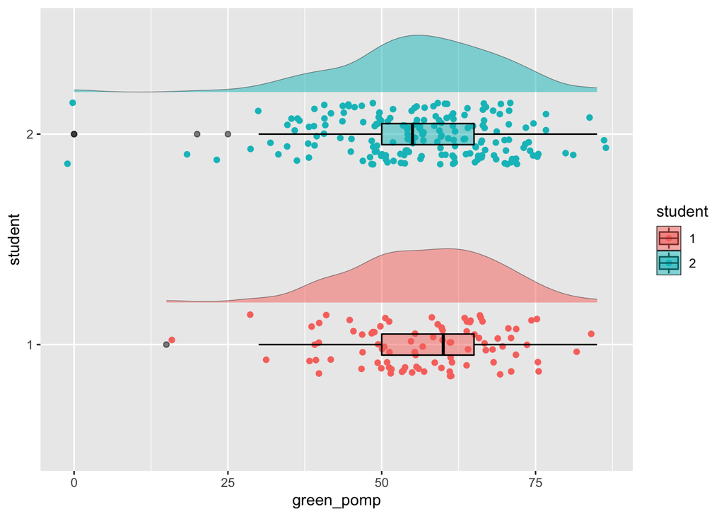

```r
## 6. Compare **green reputation** for students and non-students using a **rainfall plot** (bar + density + data points).

ggplot(na.omit(q5_data)) +
  aes(y = student,
      x = green_pomp,
      fill = student,
      color = student) +
  geom_jitter(height = .15) +
  geom_boxplot(color = "black",
               alpha = .5,
               width = .1,
               size = .5) +
  ggdist::stat_slab(height = .3,
                    color = "black",
                    size = .2,
                    alpha = .5,
                    position = position_nudge(y = .2))
```

The distributions for students and non-students seem similar, although there seem to be more data points for students, and there’s seem to be more scores clustered around the mean. There also seem to be some student outliers, which I noted in a previous graph aws well, who are scoring 0 on green reputation.

```r
## 7. Compute a summary table of means, SDs, medians, minima, and maxima for the four total scores for students and non-students.


q5_descriptives<-q5_data %>%
  group_by(student) %>%
  summarize(across(c(green_pomp:open_pomp),
            list (Mean = ~ mean(.x, na.rm = TRUE),
                SD = ~ sd(.x, na.rm = TRUE),
                Median = ~ median(.x, na.rm = TRUE),
                Min = ~ min(.x, na.rm = TRUE),
                Max = ~ max(.x, na.rm = TRUE)
            )))

descriptives<-as.data.frame(q5_descriptives)

descriptives
```

```
##   student green_pomp_Mean green_pomp_SD green_pomp_Median green_pomp_Min
## 1       1        56.81319      12.03044              60.0             15
## 2       2        55.99462      13.43473              55.0              0
## 3    <NA>        57.23684      14.31770              57.5             20
##   green_pomp_Max comp_pomp_Mean comp_pomp_SD comp_pomp_Median comp_pomp_Min
## 1             85       53.31502     6.741453         52.50000          42.5
## 2             85       51.68011     5.296614         50.00000          22.5
## 3             80       63.30618    17.438669         58.33333          42.5
##   comp_pomp_Max intel_pomp_Mean intel_pomp_SD intel_pomp_Median intel_pomp_Min
## 1          80.0        54.46276      6.541757          55.00000       37.50000
## 2          67.5        54.56840      7.895293          55.00000       17.50000
## 3         100.0        57.23684     12.025092          58.33333       41.66667
##   intel_pomp_Max open_pomp_Mean open_pomp_SD open_pomp_Median open_pomp_Min
## 1       70.00000       59.16972     6.522423               60            40
## 2       87.50000       60.41965     9.217565               60            10
## 3       83.33333       56.19570    19.720106               55            25
##   open_pomp_Max
## 1          72.5
## 2          85.0
## 3         100.0
```

Mean values and SDs for both students and non-students seem consistent across variables. Where we seem to see differences are in the minimum values, which is consistent with the graphs I created. The only variable that seems to have a clear difference is Openness, and that is just in regard to the SD, indicating a bit more spread for students than non-students.